# how_to_run

## Model

The current model is based on the article "A data-driven computational model enables integrative and mechanistic characterization of dynamic macrophage polarization". The original model needs edition to run in Python. Therefore, the edited model is provided, i.e. "edited.xml". The model receives 7 proteins and oxygen as inputs. The model deals with the variables in absolute copy number. The real inputs, however, are either `ng/ml` for proteins or `%` for oxygen. Therefore, the following sections is defined to map these units to one another,

```python
## constants
mws = { #molecular weights/ Da
    'IL1b' : 31000,
    'IFNG': 16879,
    'TNFa': 26000,
    'IL4': 20000,
    'V165a': 45000,
    'V165b': 45000,
    'IL10': 18000
}
c_2_ac = {} # concentration to absolute copy
for key,value in mws.items():
    c_2_ac[key] = (6.022*10**23)/(value*10**9)/10**6
ac_2_c = {} # absolute copy number to concentration
for key,value in c_2_ac.items():
    ac_2_c[key] = 10**6*(value*10**9)/(6.022*10**23) #TODO
c_2_ac['O2'] = 120400000/21 # % to absolute copy for oxygen
ac_2_c['02'] = 21/120400000 # absolute copy to %
```

## A showcase

To demonstrate a simple run of the model, we import the model, set an initial values of 1 ng/ml for IL4, and observe the outputs for 'IL10' for a duration of 1500 minutes.

```
Text(0,0.5,'IL10')
```

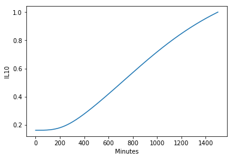

```python
import tellurium as te
import matplotlib.pyplot as plt
%config Completer.use_jedi = False
model = te.loadSBMLModel("edited.xml")
def set_ics(model): # sets the model variable
    model['IL4'] = 1*c_2_ac['IL4'] #convert from ng/ml to copy number
set_ics(model)
out_tag = 'IL10'
duration = 1500
def run(model):
    selections = [out_tag]
    model.integrator.absolute_tolerance = 1e-9
    model.integrator.relatice_tolerance = 1e-9
    results = model.simulate(start = 0, end = duration,steps = duration,
                             selections = selections)
    return results
results = run(model)
out = results[out_tag]
out = out/max(out)
fig = plt.figure()
plt.plot(out)
plt.xlabel('Minutes')
plt.ylabel(out_tag)
```

## Aim

For the first step, we want to train a neural network that produces same outputs as the given model. The trained NN should receive the given set of inputs (given below) in their given range and produce the outputs (given below) for the entire time duration of 1500 minutes with the step fo 1 minutes.

```python
i_p_range = { # input parameter ranges for sampling # user input
    'IL1b' : [0,10],#0-10 ng/ml
    'IFNG': [0,50], #valid 0-50 ng/ml
    'TNFa': [0,100], #valid 0-100 ng/ml
    'IL4': [0,100], #valid 0-100 ng/ml
    'V165a': [0.1,20], # valid. 0.1–20
    'V165b': [0,100], #
    'IL10': [0,100], #0-100 ng/ml: valid
    'O2': [0,120400000] # 0 to 27%: valid
}
o_ps = ['iNOS', 'CXCL9', 'mCXCL10', 'IFNG', 'TNFa', 'IL1b', 'IL12', 'V165b',
       'ARG1','IL1Ra','IL4','IL10','V165a'] # output parameters

duration = 1500 #minutes
```